# Billboard Top 100 - data analysis

Lucie Červenková

```r
library(billboard)
library(dplyr)
library(cluster)
library(magrittr)
library(ggpubr)
library(pls)
data("spotify_track_data")
```

## What is billboard package?

Package billboard contains data from songs on chart Billboard Hot 100 in years 1960-2015. It consists of three datasets:

- **lyrics** - the content is pretty evident from the name.
- **spotify_track_data** - track features extracted from Spotify API
- **spotify_playlists** - overview of playlists used in this collection

View documentation

Since I am interested in features describing musical elements of the songs, I will be working with **spotify_track_data**.

## Let’s see what our data looks like…

```r
colnames(spotify_track_data)
```

```
##  [1] "year"             "artist_name"      "artist_id"        "explicit"
##  [5] "track_name"       "track_id"         "danceability"     "energy"
##  [9] "key"              "loudness"         "mode"             "speechiness"
## [13] "acousticness"     "instrumentalness" "liveness"         "valence"
## [17] "tempo"            "type"             "uri"              "track_href"
## [21] "analysis_url"     "duration_ms"      "time_signature"
```

```r
DT::datatable(dplyr::filter(spotify_track_data, artist_name == "Elton John"),
      options = list(scrollX = TRUE, pageLength = 5))
```

|  | year | artist_name | artist_id | explicit | track_name | track_id | danceability | energy | key | loudness | mode | speechiness | acousticness | instrumentalness | liveness | valence | tempo | type | uri | track_href | analysis_url | duration_ms | time_signature |
| --- | --- | --- | --- | --- | --- | --- | --- | --- | --- | --- | --- | --- | --- | --- | --- | --- | --- | --- | --- | --- | --- | --- | --- |
| 1 | 1972 | Elton John | 3PhoLpVuITZKcymswpck5b | False | Rocket Man (I Think It's Going To Be A Long Long Time) | 6HqSyUwK6m9baP574cwC49 | 0.607 | 0.519 | 10 | -9.984 | 1 | 0.0285 | 0.411 | 2.67e-06 | 0.0916 | 0.35 | 136.575 | audio_features | spotify:track:6HqSyUwK6m9baP574cwC49 | https://api.spotify.com/v1/tracks/6HqSyUwK6m9baP574cwC49 | https://api.spotify.com/v1/audio-analysis/6HqSyUwK6m9baP574cwC49 | 281880 | 4 |
| 2 | 1973 | Elton John | 3PhoLpVuITZKcymswpck5b | False | Crocodile Rock | 09O3ddhGb522o4JzeMvmCo | 0.62 | 0.668 | 4 | -11.594 | 0 | 0.0358 | 0.0314 | 1.3e-05 | 0.054 | 0.97 | 149.718 | audio_features | spotify:track:09O3ddhGb522o4JzeMvmCo | https://api.spotify.com/v1/tracks/09O3ddhGb522o4JzeMvmCo | https://api.spotify.com/v1/audio-analysis/09O3ddhGb522o4JzeMvmCo | 234413 | 4 |
| 3 | 1973 | Elton John | 3PhoLpVuITZKcymswpck5b | False | Daniel | 1Z8FwTUL1VHQxcRpgtHFn6 | 0.68 | 0.505 | 0 | -11.16 | 1 | 0.0285 | 0.398 | 8.47e-05 | 0.0916 | 0.893 | 132.079 | audio_features | spotify:track:1Z8FwTUL1VHQxcRpgtHFn6 | https://api.spotify.com/v1/tracks/1Z8FwTUL1VHQxcRpgtHFn6 | https://api.spotify.com/v1/audio-analysis/1Z8FwTUL1VHQxcRpgtHFn6 | 233520 | 4 |
| 4 | 1974 | Elton John | 3PhoLpVuITZKcymswpck5b | False | Bennie And The Jets - Remastered 2014 | 3iJxloILmOu2NIRZ0OGyui | 0.666 | 0.668 | 0 | -7.961 | 1 | 0.0523 | 0.251 | 5.77e-06 | 0.499 | 0.76 | 132.666 | audio_features | spotify:track:3iJxloILmOu2NIRZ0OGyui | https://api.spotify.com/v1/tracks/3iJxloILmOu2NIRZ0OGyui | https://api.spotify.com/v1/audio-analysis/3iJxloILmOu2NIRZ0OGyui | 322549 | 4 |
| 5 | 1974 | Elton John | 3PhoLpVuITZKcymswpck5b | False | Goodbye Yellow Brick Road | 1Zcpy8cVvKW8PXBBkmWOi8 | 0.548 | 0.309 | 5 | -14.074 | 1 | 0.031 | 0.448 | 0.00086 | 0.11 | 0.368 | 121.622 | audio_features | spotify:track:1Zcpy8cVvKW8PXBBkmWOi8 | https://api.spotify.com/v1/tracks/1Zcpy8cVvKW8PXBBkmWOi8 | https://api.spotify.com/v1/audio-analysis/1Zcpy8cVvKW8PXBBkmWOi8 | 193960 | 4 |
| 6 | 1974 | Elton John | 3PhoLpVuITZKcymswpck5b | False | Don't Let The Sun Go Down On Me | 1yB9QZOFBlRtl8kUUujPoJ | 0.44 | 0.382 | 0 | -11.442 | 1 | 0.0278 | 0.0735 | 2.97e-05 | 0.15 | 0.359 | 139.566 | audio_features | spotify:track:1yB9QZOFBlRtl8kUUujPoJ | https://api.spotify.com/v1/tracks/1yB9QZOFBlRtl8kUUujPoJ | https://api.spotify.com/v1/audio-analysis/1yB9QZOFBlRtl8kUUujPoJ | 335707 | 4 |
| 7 | 1975 | Elton John | 3PhoLpVuITZKcymswpck5b | False | Philadelphia Freedom | 6OADGew7LIa4msMBoFAPpm | 0.742 | 0.405 | 0 | -15.627 | 0 | 0.0433 | 0.0611 | 0.00601 | 0.0718 | 0.755 | 125.481 | audio_features | spotify:track:6OADGew7LIa4msMBoFAPpm | https://api.spotify.com/v1/tracks/6OADGew7LIa4msMBoFAPpm | https://api.spotify.com/v1/audio-analysis/6OADGew7LIa4msMBoFAPpm | 323307 | 4 |
| 8 | 1975 | Elton John | 3PhoLpVuITZKcymswpck5b | False | Lucy In The Sky With Diamonds | 3axR3m0Obsx0SPPl9vEO72 | 0.409 | 0.371 | 0 | -15.332 | 1 | 0.0521 | 0.104 | 0.00383 | 0.124 | 0.545 | 164.77 | audio_features | spotify:track:3axR3m0Obsx0SPPl9vEO72 | https://api.spotify.com/v1/tracks/3axR3m0Obsx0SPPl9vEO72 | https://api.spotify.com/v1/audio-analysis/3axR3m0Obsx0SPPl9vEO72 | 357627 | 4 |
| 9 | 1975 | Elton John | 3PhoLpVuITZKcymswpck5b | False | Someone Saved My Life Tonight | 5i7z7K3YuFCGbYIn6OzrpA | 0.458 | 0.446 | 1 | -8.82 | 1 | 0.0279 | 0.334 | 6.28e-06 | 0.195 | 0.154 | 130.062 | audio_features | spotify:track:5i7z7K3YuFCGbYIn6OzrpA | https://api.spotify.com/v1/tracks/5i7z7K3YuFCGbYIn6OzrpA | https://api.spotify.com/v1/audio-analysis/5i7z7K3YuFCGbYIn6OzrpA | 407440 | 4 |
| 10 | 1976 | Elton John | 3PhoLpVuITZKcymswpck5b | False | Island Girl | 08B1GlqMkG7nFXUZpc4C5P | 0.708 | 0.9 | 10 | -7.776 | 1 | 0.0652 | 0.104 | 4.81e-06 | 0.29 | 0.441 | 139.886 | audio_features | spotify:track:08B1GlqMkG7nFXUZpc4C5P | https://api.spotify.com/v1/tracks/08B1GlqMkG7nFXUZpc4C5P | https://api.spotify.com/v1/audio-analysis/08B1GlqMkG7nFXUZpc4C5P | 222147 | 4 |

[output cut: 18 more lines]

- I selected tracks by *Elton John* :-)
- There is a number of columns which contain ID’s and links, which are irrelevant for my purpose. Let’s get rid of them!

```r
data <- dplyr::select(spotify_track_data, -c("artist_id", "track_id", "explicit", "type", "uri", "track_href", "analysis_url"))
DT::datatable(dplyr::filter(data, artist_name == "Elton John"),
      options = list(scrollX = TRUE, pageLength = 5))
```

|  | year | artist_name | track_name | danceability | energy | key | loudness | mode | speechiness | acousticness | instrumentalness | liveness | valence | tempo | duration_ms | time_signature |
| --- | --- | --- | --- | --- | --- | --- | --- | --- | --- | --- | --- | --- | --- | --- | --- | --- |
| 1 | 1972 | Elton John | Rocket Man (I Think It's Going To Be A Long Long Time) | 0.607 | 0.519 | 10 | -9.984 | 1 | 0.0285 | 0.411 | 2.67e-06 | 0.0916 | 0.35 | 136.575 | 281880 | 4 |
| 2 | 1973 | Elton John | Crocodile Rock | 0.62 | 0.668 | 4 | -11.594 | 0 | 0.0358 | 0.0314 | 1.3e-05 | 0.054 | 0.97 | 149.718 | 234413 | 4 |
| 3 | 1973 | Elton John | Daniel | 0.68 | 0.505 | 0 | -11.16 | 1 | 0.0285 | 0.398 | 8.47e-05 | 0.0916 | 0.893 | 132.079 | 233520 | 4 |
| 4 | 1974 | Elton John | Bennie And The Jets - Remastered 2014 | 0.666 | 0.668 | 0 | -7.961 | 1 | 0.0523 | 0.251 | 5.77e-06 | 0.499 | 0.76 | 132.666 | 322549 | 4 |
| 5 | 1974 | Elton John | Goodbye Yellow Brick Road | 0.548 | 0.309 | 5 | -14.074 | 1 | 0.031 | 0.448 | 0.00086 | 0.11 | 0.368 | 121.622 | 193960 | 4 |
| 6 | 1974 | Elton John | Don't Let The Sun Go Down On Me | 0.44 | 0.382 | 0 | -11.442 | 1 | 0.0278 | 0.0735 | 2.97e-05 | 0.15 | 0.359 | 139.566 | 335707 | 4 |
| 7 | 1975 | Elton John | Philadelphia Freedom | 0.742 | 0.405 | 0 | -15.627 | 0 | 0.0433 | 0.0611 | 0.00601 | 0.0718 | 0.755 | 125.481 | 323307 | 4 |
| 8 | 1975 | Elton John | Lucy In The Sky With Diamonds | 0.409 | 0.371 | 0 | -15.332 | 1 | 0.0521 | 0.104 | 0.00383 | 0.124 | 0.545 | 164.77 | 357627 | 4 |
| 9 | 1975 | Elton John | Someone Saved My Life Tonight | 0.458 | 0.446 | 1 | -8.82 | 1 | 0.0279 | 0.334 | 6.28e-06 | 0.195 | 0.154 | 130.062 | 407440 | 4 |
| 10 | 1976 | Elton John | Island Girl | 0.708 | 0.9 | 10 | -7.776 | 1 | 0.0652 | 0.104 | 4.81e-06 | 0.29 | 0.441 | 139.886 | 222147 | 4 |

[output cut: 18 more lines]

For the purposes of data analysis I am going to create column “decade” which will come in useful later.

```r
data$year = as.numeric(data$year)
data <- data %>% dplyr::mutate(., decade = year - year %% 10)

DT::datatable(dplyr::filter(data, artist_name == "Elton John"),
      options = list(scrollX = TRUE, pageLength = 5))
```

|  | year | artist_name | track_name | danceability | energy | key | loudness | mode | speechiness | acousticness | instrumentalness | liveness | valence | tempo | duration_ms | time_signature | decade |
| --- | --- | --- | --- | --- | --- | --- | --- | --- | --- | --- | --- | --- | --- | --- | --- | --- | --- |
| 1 | 1972 | Elton John | Rocket Man (I Think It's Going To Be A Long Long Time) | 0.607 | 0.519 | 10 | -9.984 | 1 | 0.0285 | 0.411 | 2.67e-06 | 0.0916 | 0.35 | 136.575 | 281880 | 4 | 1970 |
| 2 | 1973 | Elton John | Crocodile Rock | 0.62 | 0.668 | 4 | -11.594 | 0 | 0.0358 | 0.0314 | 1.3e-05 | 0.054 | 0.97 | 149.718 | 234413 | 4 | 1970 |
| 3 | 1973 | Elton John | Daniel | 0.68 | 0.505 | 0 | -11.16 | 1 | 0.0285 | 0.398 | 8.47e-05 | 0.0916 | 0.893 | 132.079 | 233520 | 4 | 1970 |
| 4 | 1974 | Elton John | Bennie And The Jets - Remastered 2014 | 0.666 | 0.668 | 0 | -7.961 | 1 | 0.0523 | 0.251 | 5.77e-06 | 0.499 | 0.76 | 132.666 | 322549 | 4 | 1970 |
| 5 | 1974 | Elton John | Goodbye Yellow Brick Road | 0.548 | 0.309 | 5 | -14.074 | 1 | 0.031 | 0.448 | 0.00086 | 0.11 | 0.368 | 121.622 | 193960 | 4 | 1970 |
| 6 | 1974 | Elton John | Don't Let The Sun Go Down On Me | 0.44 | 0.382 | 0 | -11.442 | 1 | 0.0278 | 0.0735 | 2.97e-05 | 0.15 | 0.359 | 139.566 | 335707 | 4 | 1970 |
| 7 | 1975 | Elton John | Philadelphia Freedom | 0.742 | 0.405 | 0 | -15.627 | 0 | 0.0433 | 0.0611 | 0.00601 | 0.0718 | 0.755 | 125.481 | 323307 | 4 | 1970 |
| 8 | 1975 | Elton John | Lucy In The Sky With Diamonds | 0.409 | 0.371 | 0 | -15.332 | 1 | 0.0521 | 0.104 | 0.00383 | 0.124 | 0.545 | 164.77 | 357627 | 4 | 1970 |
| 9 | 1975 | Elton John | Someone Saved My Life Tonight | 0.458 | 0.446 | 1 | -8.82 | 1 | 0.0279 | 0.334 | 6.28e-06 | 0.195 | 0.154 | 130.062 | 407440 | 4 | 1970 |
| 10 | 1976 | Elton John | Island Girl | 0.708 | 0.9 | 10 | -7.776 | 1 | 0.0652 | 0.104 | 4.81e-06 | 0.29 | 0.441 | 139.886 | 222147 | 4 | 1970 |

[output cut: 18 more lines]

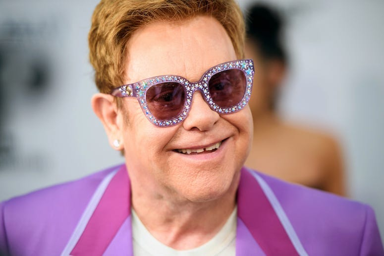

Amazing! Now we can start analysing.

## Cluster analysis

- Since my data set contains so many different styles of music over 6 decades, I would like to see if there is a clear division between them.
- For this purpose I will use cluster analysis. Let’s start by excluding non-numeric columns and perfom hierarchical clustering.

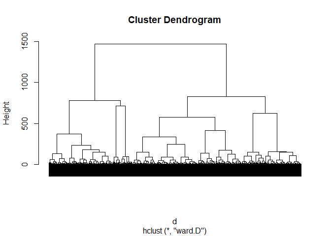

```r
data.stand <- scale(dplyr::select(data,-c("year", "decade", "artist_name", "track_name")))

d <- dist(data.stand, method = "euclidean")

fit <- hclust(d, method="ward.D")

plot(fit, labels = FALSE)
```

- In this initial step I wanted to see if there is a way for me to estimate optimal number of clusters for K-means.
- It looks like 3 or 4 could be and option. But let’s not jump to conclusions just yet!

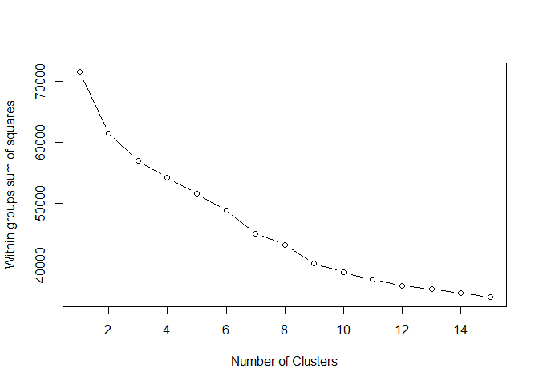

```r
wssplot <- function(data, nc=15, seed=1234){
  wss <- (nrow(data)-1)*sum(apply(data,2,var))
  for (i in 2:nc){
    set.seed(seed)
    wss[i] <- sum(kmeans(data, centers=i)$withinss)}
  plot(1:nc, wss, type="b", xlab="Number of Clusters",
       ylab="Within groups sum of squares")}

wssplot(data.stand)
```

- Well… this is not the kind of graph I was hoping for. :D
- Initially the curve exponentially decreases, but something strange is happening around 6-10 clusters, where the curve is not so smooth.
- I do not have high expectations from this, but I will try with 10 clusters. Hopefully these will reflect differences among songs from different decades!

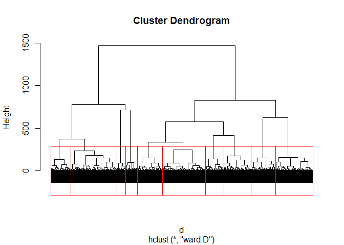

```r
plot(fit,labels = FALSE)
groups <- cutree(fit, k=10)

rect.hclust(fit, k=10, border="red")
```

```r
k.means.fit <- kmeans(data.stand, 10)
k.means.fit$cluster[1:978]
```

```
##   [1]  4  3  8  9  3  8  8  8  8  8  8  3  9  3  8  8  8  8  8  3  3  3  9  4  8
##  [26]  8  8  8  9  9  8  8  8  9  9  8  4  3  8  8  9  9  3  8  8  8  8  9  4  8
##  [51]  9  8  3  4  8  3  3  4  9  9  8  9  3  8  8  8  3  3  3  8  9  8  8  3  8
##  [76]  8  8  7  3  8  4  8  8  8  9  8  8  4  8  8  9  3  8  8  8  8  8  8  9  9
## [101]  8  9  9  9  7  3  6  8  3  8  4  9  3  9  4  2  4  9  7  9  8  2  8  2  8
## [126]  8  8  9  8  9  2  8  8  8  4  3  4  3  8  8  3  9  8  4  8  8  4  3  6  3
## [151]  8  3  8  8  4  9  8  3  7  4  3  2  8  8  2  5  8  8  3  6  7  4  8  8  8
## [176]  3  7  3  2  9  8  8  9  9  2  8  2  4  8  9  8  8  3  8  9  3  8  2  8  8
## [201]  4  9  8  9  4  9  8  6  6  9  8  6  8  8  8  8  6  9  8  8  4  8  8  7  6
## [226]  3  8  9  9  9  9  9  6  8  3  1  8  4  8  3  4  8  8  8  7  8  9  8  9  8
## [251]  3  8  8  4  3  3  8  9  3  8  4  3  1  8  8  3  8  9  8  6  8  8  3  8  3
## [276]  3  8  8  8  3  8  8  8  9  4  4  3 10  9  4  7  8  8 10  8  8  8  9  8  9
## [301]  8  8  3  8  8  3  3  1  8  3  8  8  9  8  2  9  9  3  3  4  9  4  9  8  2
## [326]  2  4  8  8  8  1  8  8  8  8  3  2  7  8  8  4  8  8  9  6  8  6  9  8  2
## [351]  9  9  3  8  9  6  7  4  8  4  6  9  9  9  3  9  2  6  8  8  8  8  8  8  8
```

[output cut: 25 more lines]

```r
data$decade[1:978]
```

```
##   [1] 1960 1960 1960 1960 1960 1960 1960 1960 1960 1960 1960 1960 1960 1960 1960
##  [16] 1960 1960 1960 1960 1960 1960 1960 1960 1960 1960 1960 1960 1960 1960 1960
##  [31] 1960 1960 1960 1960 1960 1960 1960 1960 1960 1960 1960 1960 1960 1960 1960
##  [46] 1960 1960 1960 1960 1960 1960 1960 1960 1960 1960 1960 1960 1960 1960 1960
##  [61] 1960 1960 1960 1960 1960 1960 1960 1960 1960 1960 1960 1960 1960 1960 1960
##  [76] 1960 1960 1960 1960 1960 1960 1960 1960 1960 1960 1960 1960 1960 1960 1960
##  [91] 1960 1960 1960 1960 1960 1960 1960 1960 1960 1960 1960 1960 1960 1960 1960
## [106] 1960 1960 1960 1960 1960 1960 1960 1960 1960 1960 1960 1960 1960 1960 1960
## [121] 1960 1960 1960 1960 1960 1960 1960 1960 1960 1960 1960 1960 1960 1960 1960
## [136] 1960 1960 1960 1960 1960 1960 1960 1960 1960 1960 1960 1960 1960 1960 1960
## [151] 1960 1960 1960 1960 1960 1960 1960 1960 1960 1960 1960 1960 1960 1960 1960
## [166] 1960 1960 1960 1960 1960 1960 1960 1960 1960 1960 1960 1960 1960 1960 1960
## [181] 1960 1960 1960 1960 1960 1960 1960 1960 1960 1960 1960 1960 1960 1960 1960
## [196] 1960 1960 1960 1960 1960 1960 1960 1960 1960 1960 1960 1960 1960 1960 1960
## [211] 1960 1960 1960 1960 1960 1960 1960 1960 1960 1960 1960 1960 1960 1960 1960
```

[output cut: 51 more lines]

- It is already clear, that decade of the song is not such a factor when it comes to assigning them into groups.

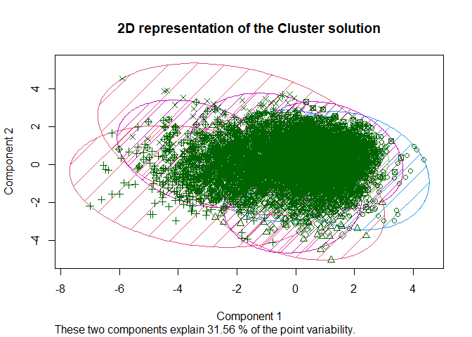

```r
clusplot(data.stand, k.means.fit$cluster, main='2D representation of the Cluster solution',
         color=TRUE, shade=TRUE)
```

- This is just a big mess :-(
- Moral of the story - you cannot easily label songs based on which decade they are from (at least not from given variables).

## MANOVA

- Having so many data points (songs) can make it hard to orient in them.
- Some of the features (variable/columns) are not very self-explanatory, so it would be useful to view some basic explanatory statistics.

```r
data.numeric <- dplyr::select(data, -c('decade', 'year', 'artist_name', 'track_name'))
summary(data.numeric)
```

```
##   danceability        energy            key            loudness
##  Min.   :0.1330   Min.   :0.0204   Min.   : 0.000   Min.   :-33.987
##  1st Qu.:0.5210   1st Qu.:0.4820   1st Qu.: 2.000   1st Qu.:-10.783
##  Median :0.6330   Median :0.6380   Median : 5.000   Median : -7.944
##  Mean   :0.6192   Mean   :0.6234   Mean   : 5.291   Mean   : -8.513
##  3rd Qu.:0.7230   3rd Qu.:0.7790   3rd Qu.: 8.000   3rd Qu.: -5.782
##  Max.   :0.9860   Max.   :0.9970   Max.   :11.000   Max.   : -0.166
##       mode         speechiness       acousticness       instrumentalness
##  Min.   :0.0000   Min.   :0.02150   Min.   :0.0000155   Min.   :0.0000000
##  1st Qu.:0.0000   1st Qu.:0.03180   1st Qu.:0.0446000   1st Qu.:0.0000000
##  Median :1.0000   Median :0.04070   Median :0.1750000   Median :0.0000049
##  Mean   :0.7058   Mean   :0.06822   Mean   :0.2667522   Mean   :0.0285532
##  3rd Qu.:1.0000   3rd Qu.:0.06440   3rd Qu.:0.4360000   3rd Qu.:0.0004300
##  Max.   :1.0000   Max.   :0.61300   Max.   :0.9860000   Max.   :0.9840000
##     liveness         valence           tempo         duration_ms
##  Min.   :0.0117   Min.   :0.0361   Min.   : 36.71   Min.   :  62827
##  1st Qu.:0.0853   1st Qu.:0.4290   1st Qu.: 99.11   1st Qu.: 194067
##  Median :0.1230   Median :0.6440   Median :118.52   Median : 229773
##  Mean   :0.1833   Mean   :0.6145   Mean   :119.58   Mean   : 232203
##  3rd Qu.:0.2330   3rd Qu.:0.8140   3rd Qu.:133.81   3rd Qu.: 263779
##  Max.   :0.9910   Max.   :0.9850   Max.   :213.84   Max.   :1561133
##  time_signature
##  Min.   :1.000
##  1st Qu.:4.000
##  Median :4.000
##  Mean   :3.957
##  3rd Qu.:4.000
##  Max.   :5.000
```

To me, it always seemed like new songs got significantly shorter compared to older ones.

- Obviously, songs that were too long (e.g. ‘Shine On You Crazy Diamond’ by *Pink Floyd*, 1975 was 26 minutes long) were not suitable for radio broadcast and therefore are not expected to be abundantly found in this dataset.
- However, the longest track in this dataset has a little over 26 minutes (‘Tubular Bells - Pt. I’ by *Mike Oldfield*, 1974).
- The shortest track is only 1 minute long (‘Main Title Theme’ by *Danny Elfman*, 1996) and is way newer.

Now, I would like to perform ANOVA over songs from different decades to see if my hypothesis is correct. But first, let’s check if my data pass the assumptions.

1. Normality

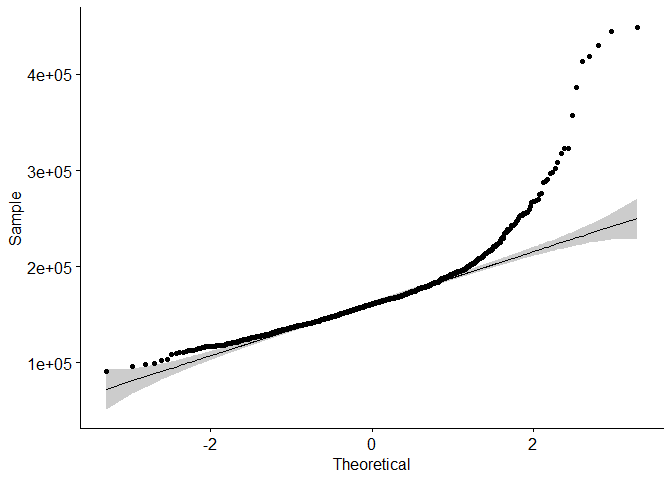

```r
data_60s <- data %>% dplyr::filter(., decade == 1960)
data_70s <- data %>% dplyr::filter(., decade == 1970)
data_80s <- data %>% dplyr::filter(., decade == 1980)
data_90s <- data %>% dplyr::filter(., decade == 1990)
data_00s <- data %>% dplyr::filter(., decade == 2000)
data_10s <- data %>% dplyr::filter(., decade == 2010)


ggqqplot(data_60s$duration_ms)
```

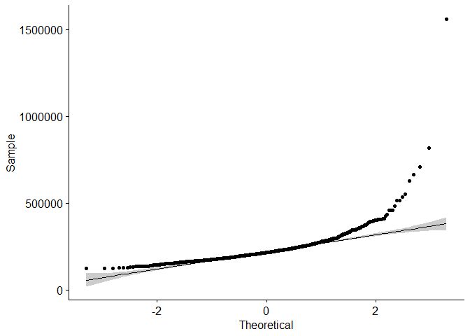

```r
ggqqplot(data_70s$duration_ms)
```

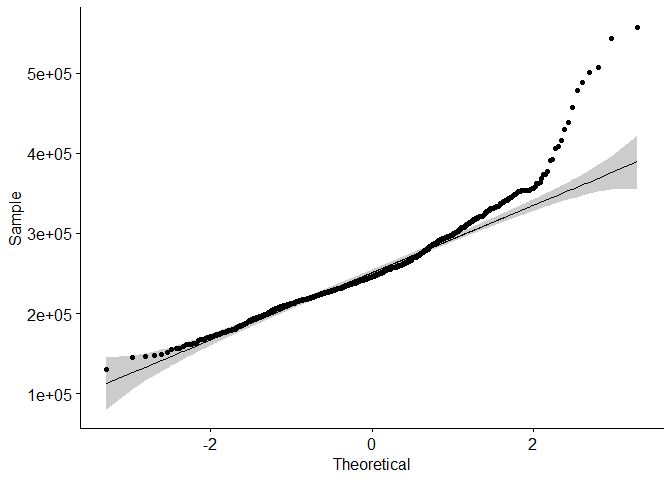

```r
ggqqplot(data_80s$duration_ms)
```

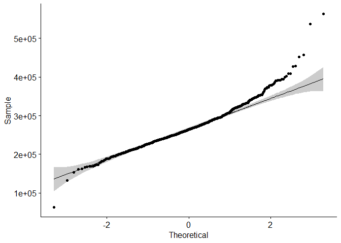

```r
ggqqplot(data_90s$duration_ms)
```

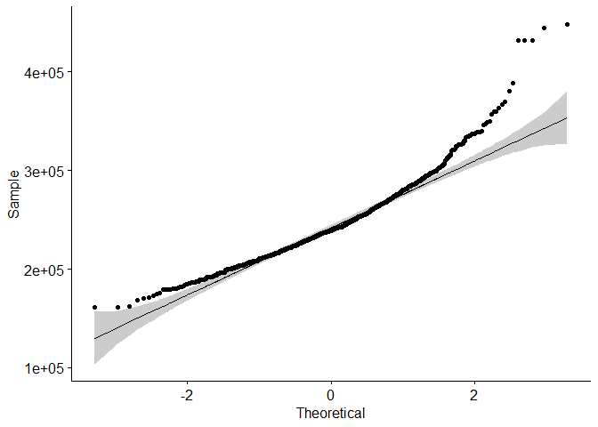

```r
ggqqplot(data_00s$duration_ms)
```

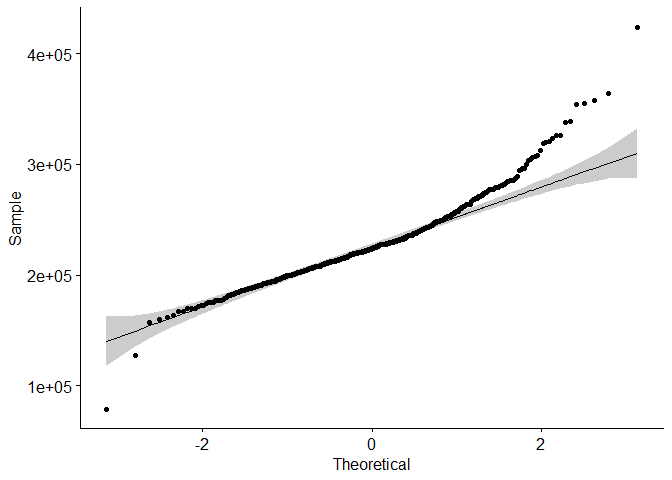

```r
ggqqplot(data_10s$duration_ms)
```

- None of these Q-Q plots suggests that I am dealing with Normal distribution. :-( This is especially evident in 60’s and 70’s. Probably it is because there were either very long or very short (radio-friendly) songs.
- Let’s exclude 60-80’s and try to test normality of later decades.

```r
shapiro.test(data_90s$duration_ms)
```

```
##
##  Shapiro-Wilk normality test
##
## data:  data_90s$duration_ms
## W = 0.95973, p-value = 7.365e-16
```

```r
shapiro.test(data_00s$duration_ms)
```

```
##
##  Shapiro-Wilk normality test
##
## data:  data_00s$duration_ms
## W = 0.93808, p-value < 2.2e-16
```

```r
shapiro.test(data_10s$duration_ms)
```

```
##
##  Shapiro-Wilk normality test
##
## data:  data_10s$duration_ms
## W = 0.94069, p-value = 2.762e-14
```

Whoa… in neither of the three decades is the p-value in Shapiro-Wilk normality test bigger than 0.05 and thus I cannot assume normality of the data.

Let’s try to see if any other variables are ANOVA/MANOVA-friendly. In other words, let’s take random decade and run Shapiro-Wilk normality test on all other numeric variables.

```r
shapiro.test(data_80s$instrumentalness)$p.value
```

```
## [1] 9.647598e-53
```

```r
shapiro.test(data_80s$danceability)$p.value
```

```
## [1] 6.010064e-07
```

```r
shapiro.test(data_80s$energy)$p.value
```

```
## [1] 1.61784e-11
```

```r
shapiro.test(data_80s$loudness)$p.value
```

```
## [1] 3.71626e-10
```

```r
shapiro.test(data_80s$key)$p.value
```

```
## [1] 3.395737e-22
```

```r
shapiro.test(data_80s$speechiness)$p.value
```

```
## [1] 3.407915e-41
```

```r
shapiro.test(data_80s$mode)$p.value
```

```
## [1] 1.236379e-43
```

```r
shapiro.test(data_80s$acousticness)$p.value
```

```
## [1] 8.859059e-28
```

```r
shapiro.test(data_80s$liveness)$p.value
```

```
## [1] 7.670109e-37
```

```r
shapiro.test(data_80s$valence)$p.value
```

```
## [1] 4.623224e-21
```

```r
shapiro.test(data_80s$tempo)$p.value
```

```
## [1] 5.231083e-13
```

```r
shapiro.test(data_80s$time_signature)$p.value
```

```
## [1] 1.323568e-54
```

This is surprising. With the amount of data I have I would expect Central Limit Theorem to make the data converge to normality. Since this is not true, I have to give up on ANOVA/MANOVA tests with this data set.

[figure not shown]

## PCR and Linear Regression

In my dataset there are some *exotic* variables such as ‘energy’ and ‘danceability’.

One by one, I will investigate, whether they can be predicted using the set of the remaining variables.

```r
train<-sample(c(T,F),nrow(data.numeric),rep=T)
test<-(!train)
```

### Energy

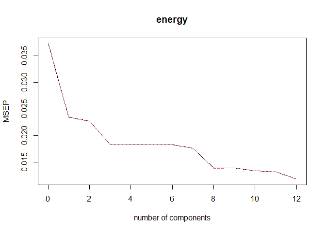

```r
pcr_model<-pcr(energy~., data = data.numeric, subset = train, scale = T, validation = "CV")
validationplot(pcr_model, val.type="MSEP")
```

It looks like 9 or 10 components could be an optimal choice!

```r
pcr_prediction_9<-predict(pcr_model, data.numeric[test,], ncomp = 9)
pcr_prediction_10<-predict(pcr_model, data.numeric[test,], ncomp = 10)
```

Which one is better? Let’s use MSE as an evaluation measure.

```r
mean((pcr_prediction_9 - data.numeric$energy[test])^2)
```

```
## [1] 0.01338479
```

```r
mean((pcr_prediction_10 - data.numeric$energy[test])^2)
```

```
## [1] 0.01304928
```

MSE suggests that 10 components is a slightly better choice. :-)

Let’s compare this with classical linear regression.

```r
lm_fit<-lm(energy~.,data=data.numeric, subset = train)
lm_predikce<-predict(lm_fit,data.numeric[test,])

mean((lm_predikce-data.numeric$energy[test])^2)
```

```
## [1] 0.01126744
```

Linear regression performs even better!

```r
summary(lm_fit)
```

```
##
## Call:
## lm(formula = energy ~ ., data = data.numeric, subset = train)
##
## Residuals:
##      Min       1Q   Median       3Q      Max
## -0.32456 -0.07329 -0.00007  0.06819  0.45890
##
## Coefficients:
##                    Estimate Std. Error t value Pr(>|t|)
## (Intercept)       6.524e-01  3.735e-02  17.466  < 2e-16 ***
## danceability     -1.509e-01  1.761e-02  -8.567  < 2e-16 ***
## key               3.163e-04  5.920e-04   0.534  0.59319
## loudness          3.043e-02  6.445e-04  47.218  < 2e-16 ***
## mode             -2.767e-03  4.665e-03  -0.593  0.55314
## speechiness      -3.339e-02  3.027e-02  -1.103  0.27011
## acousticness     -2.293e-01  9.422e-03 -24.336  < 2e-16 ***
## instrumentalness  7.026e-02  1.674e-02   4.198 2.78e-05 ***
## liveness          1.113e-01  1.334e-02   8.340  < 2e-16 ***
## valence           2.734e-01  1.050e-02  26.043  < 2e-16 ***
## tempo             2.173e-04  7.880e-05   2.758  0.00586 **
## duration_ms       1.183e-07  3.789e-08   3.122  0.00182 **
## time_signature    3.605e-02  8.221e-03   4.385 1.20e-05 ***
## ---
## Signif. codes:  0 '***' 0.001 '**' 0.01 '*' 0.05 '.' 0.1 ' ' 1
##
## Residual standard error: 0.1082 on 2735 degrees of freedom
## Multiple R-squared:  0.6879, Adjusted R-squared:  0.6865
## F-statistic: 502.3 on 12 and 2735 DF,  p-value: < 2.2e-16
```

Let’s try it again, but this time consider only significant features.

```r
data.numeric.subset <- data.numeric %>% dplyr::select(., -c('key', 'mode', 'speechiness'))
lm_fit<-lm(energy~.,data=data.numeric.subset, subset = train)
lm_predikce<-predict(lm_fit,data.numeric.subset[test,])

mean((lm_predikce-data.numeric.subset$energy[test])^2)
```

```
## [1] 0.01123072
```

A little improvement :-)

### Danceability

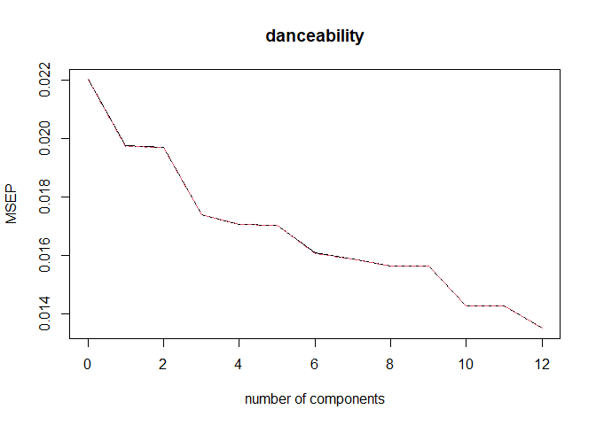

```r
pcr_model<-pcr(danceability~., data = data.numeric, subset = train, scale = T, validation = "CV")
validationplot(pcr_model, val.type="MSEP")
```

This time I will select 11 components for PCR.

```r
pcr_prediction_11<-predict(pcr_model, data.numeric[test,], ncomp = 11)
mean((pcr_prediction_11 - data.numeric$danceability[test])^2)
```

```
## [1] 0.0146015
```

MSE is slightly worse compared to ‘energy’ prediction, but still looks reasonable.

```r
lm_fit<-lm(danceability~.,data=data.numeric, subset = train)
lm_predikce<-predict(lm_fit,data.numeric[test,])

mean((lm_predikce-data.numeric$danceability[test])^2)
```

```
## [1] 0.01407359
```

Again, linear regression improves the MSE.

```r
summary(lm_fit)
```

```
##
## Call:
## lm(formula = danceability ~ ., data = data.numeric, subset = train)
##
## Residuals:
##      Min       1Q   Median       3Q      Max
## -0.40318 -0.07201  0.00866  0.07898  0.35874
##
## Coefficients:
##                    Estimate Std. Error t value Pr(>|t|)
## (Intercept)       5.626e-01  4.079e-02  13.791  < 2e-16 ***
## energy           -1.732e-01  2.022e-02  -8.567  < 2e-16 ***
## key               3.135e-04  6.343e-04   0.494    0.621
## loudness          6.003e-03  9.232e-04   6.502 9.37e-11 ***
## mode             -2.422e-02  4.976e-03  -4.867 1.20e-06 ***
## speechiness       2.453e-01  3.210e-02   7.642 2.94e-14 ***
## acousticness     -1.251e-01  1.087e-02 -11.506  < 2e-16 ***
## instrumentalness  2.877e-02  1.798e-02   1.600    0.110
## liveness         -9.989e-02  1.435e-02  -6.960 4.23e-12 ***
## valence           3.215e-01  1.096e-02  29.340  < 2e-16 ***
## tempo            -1.178e-03  8.148e-05 -14.453  < 2e-16 ***
## duration_ms       2.716e-07  4.034e-08   6.734 2.00e-11 ***
## time_signature    3.626e-02  8.812e-03   4.116 3.98e-05 ***
## ---
## Signif. codes:  0 '***' 0.001 '**' 0.01 '*' 0.05 '.' 0.1 ' ' 1
##
## Residual standard error: 0.1159 on 2735 degrees of freedom
## Multiple R-squared:  0.3919, Adjusted R-squared:  0.3892
## F-statistic: 146.9 on 12 and 2735 DF,  p-value: < 2.2e-16
```

```r
data.numeric.subset <- data.numeric %>% dplyr::select(., -c('key', 'instrumentalness'))
lm_fit<-lm(danceability~.,data=data.numeric.subset, subset = train)
lm_predikce<-predict(lm_fit,data.numeric.subset[test,])

mean((lm_predikce-data.numeric.subset$danceability[test])^2)
```

```
## [1] 0.01403465
```

Minor improvement again. :-)

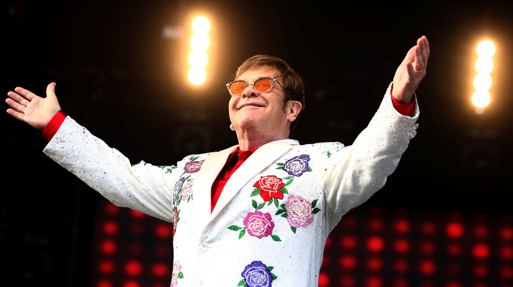

## Conclusion

While an average person can tell the difference between song from 60’s and song from 10’s after hearing them for a first time, it is a subjective impression which cannot be easily quantified. Even though, there are many different genres of songs, variables such as ‘tempo’, ‘key’ and ‘speechiness’ are not enough to spot a clear division between them. One could argue, if such strict division exists at all, since past 70 years of music proved to yield number of crossover genres (a good example of this could be ‘Bohemian Rhapsody’ by *Queen*). Such diversity can also be the reason for unconventional distribution of the data. On the other hand, I succeeded in showing that variables ‘energy’ and ‘danceability’ can be predicted using a large number of features.

To sum up, music is a beautiful and diverse form of art which can hardly be explained using mathematical measurements. Perhaps, that is why different people prefer different kind of music and one cannot possibly tell, which one is the best (genre-wise or decade-wise). Instead of fighting about it, we’d all better calm down and listen to *Elton John*. :-)